```python
import numpy as np
import matplotlib.pyplot as plt
from scipy.stats import norm, gamma, beta, uniform, sem
from scipy.linalg import norm as la_norm
```

# Question 7.6

Sampling from the standard normal distribution $10^5$ times, calculate a Monte Carlo estimate of the value of $\int_{3}^{\infty}e^{\frac{x^2}{2}}dx$, and estimate the standard error. Repeat the problem, sampling instead from $\mathcal{N}(3,1)$, as in (7.2).

```python
# Sample from standard norm
n = 10**5
sample = np.random.normal(0, 1, n)
mask = sample > 3
integrated_values = mask * np.exp(-sample**2 / 2) / norm.pdf(sample, loc=0, scale=1)
estimate = np.mean(integrated_values)
std_err = sem(integrated_values)
print(f"Estimate of Standard Norm for integral: {estimate}")
print(f"Standard Error for Standard Norm of integral: {std_err}")

# Sample from N(3, 1)
sample = np.random.normal(3, 1, n)
mask = sample > 3
integrated_values = mask * np.exp(-sample**2 / 2) / norm.pdf(sample, loc=3, scale=1)
estimate = np.mean(integrated_values)
std_err = sem(integrated_values)
print(f"Estimate of N(3, 1) for integral: {estimate}")
print(f"Standard Error for N(3, 1) of integral: {std_err}")
```

```
Estimate of Standard Norm for integral: 0.003759942411946499
Standard Error for Standard Norm of integral: 0.0003067692113165406
Estimate of N(3, 1) for integral: 0.003415689751475596
Standard Error for N(3, 1) of integral: 1.9783570413087878e-05
```

# Question 7.7

Use importance sampling, drawing from Beta $(a,b)$ for various values of $a$ and $b$, to estimate the integral $\int_{0}^{2\pi}\frac{dx}{x^3+x+1}$. Find values of $a$, and $b$ and sample size $n$ that give a standard error less than $10^{-3}$.

Hint: The domain of Beta $(a,b)$ is [0,1], but the integral is to be evaluated over $[0,2\pi]$, so you will need to do a change of variables to be able to calculate this with samples from Beta $(a,b)$.

```python
a = 1
b = 2
n = 10**6

sample = np.random.beta(a, b, n)
integrated_values = ((2 * np.pi) / ((2*np.pi*sample)**3 + 2*np.pi*sample + 1)) / beta.pdf(sample, a, b)
estimate = np.mean(integrated_values)
std_err = sem(integrated_values)
print(f"Estimate of Beta(1, 2) with 10^6 values for integral: {estimate}")
print(f"Standard Error for Beta(1, 2) with 10^6 values of integral: {std_err}")
```

```
Estimate of Beta(1, 2) with 10^6 values for integral: 0.909714137990387
Standard Error for Beta(1, 2) with 10^6 values of integral: 0.0008914517670902453
```

# Question 7.8.iii

iii) Thus, a draw from the exponential distribution can be constructed by drawing $u$ from Uniform(0,1) and computing $- \frac{\log(1-y)}{\lambda}$. Write code to implement this, and use your code to draw $10^5$ times from Gamma(1,2). Plot a normed histogram of your results, and, on the same graph, plot the pdf of the exponential distribution for comparison.

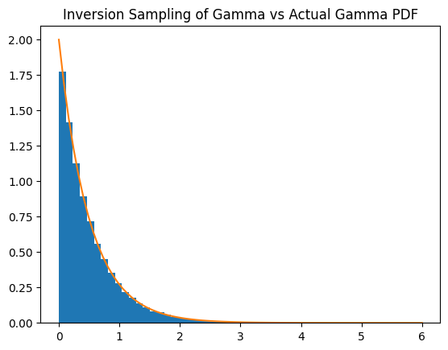

```python
n = 10**5
mu_sample = np.random.uniform(0, 1, n)
mu_sample = -np.log(mu_sample) / 2
x = np.linspace(0, 6, 75)

plt.hist(mu_sample, bins=50, density=True)
plt.plot(x, gamma.pdf(x, a=1, scale=1/2))
plt.title("Inversion Sampling of Gamma vs Actual Gamma PDF")
plt.show()
```

# Question 7.9.ii-iii

ii) Code up the inversion sampling algorithm to sample from the logistic distribution, and use your code to deaw from the logisitc distribution $10^5$ times. Plot a normed histogram of your results, and on the same graph plot the pdf of the logistic distribution for comparison.

iii) Using your sample, estimate the mean and variance of the distribution.

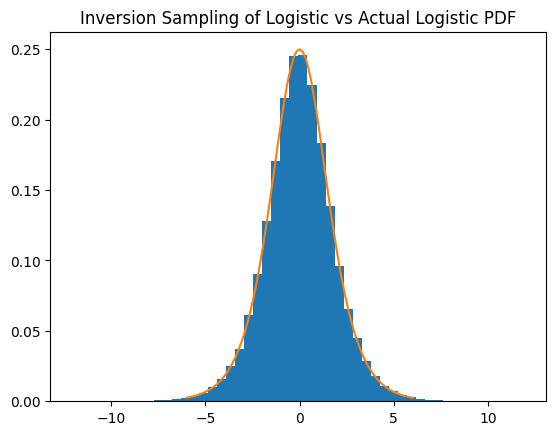

```
The mean of the logistic inversion sample is: 0.007443467188589279
The variance of the logistic inversion sample is: 3.2865792761058827
```

```python
# Part ii) sample and plot the logistic distribution
n = 10**5
mu_sample = np.random.uniform(0, 1, n)
mu_sample = -np.log(1 / mu_sample - 1)
x = np.linspace(-6, 6, 75)

plt.hist(mu_sample, bins=50, density=True)
plt.plot(x, np.exp(-x) / (1 + np.exp(-x))**2)
plt.title("Inversion Sampling of Logistic vs Actual Logistic PDF")
plt.show()

print(F"The mean of the logistic inversion sample is: {np.mean(mu_sample)}")
print(F"The variance of the logistic inversion sample is: {np.var(mu_sample)}")
```

# Question 7.10

Code up a method for estimating the volume oof the unit ball in $d$-dimensional space using rejection sampling. Compute estimates for these values for $d\in \{1,\dots,10\}$ using enough samples to get a standard error less than $10^{-2}$.

```python
n = 10**6
for d in [1, 2, 3, 4, 5, 6, 7, 8, 9, 10]:
    # Find the uniform sample, normalize it to see what distances are within the unit ball
    sample = np.random.uniform(-1, 1, size=(d, n))
    norm_sample = la_norm(sample, axis=0) <= 1
    mean_norm_sample = np.mean(norm_sample)
    # Calculate estimated vollume and standard error
    est_vol = mean_norm_sample * 2**d
    std_err = np.std(norm_sample) / np.sqrt(n)

    print(F"Estimated Volume of {d} dimension ball: {est_vol}")
    print(F"Standard Error of the ball is: {std_err}")
```

```
Estimated Volume of 1 dimension ball: 2.0
Standard Error of the ball is: 0.0
Estimated Volume of 2 dimension ball: 3.140184
Standard Error of the ball is: 0.0004107904306139568
Estimated Volume of 3 dimension ball: 4.19224
Standard Error of the ball is: 0.0004994222252763688
Estimated Volume of 4 dimension ball: 4.933632
Standard Error of the ball is: 0.00046181278035151873
Estimated Volume of 5 dimension ball: 5.268
Standard Error of the ball is: 0.00037084175786310795
Estimated Volume of 6 dimension ball: 5.169664
Standard Error of the ball is: 0.0002724908031915939
Estimated Volume of 7 dimension ball: 4.737536
Standard Error of the ball is: 0.00018879118585357743
Estimated Volume of 8 dimension ball: 4.09984
Standard Error of the ball is: 0.00012553294298709006
Estimated Volume of 9 dimension ball: 3.249152
Standard Error of the ball is: 7.940861593051473e-05
Estimated Volume of 10 dimension ball: 2.531328
Standard Error of the ball is: 4.965772060817936e-05
```

# Question 7.11

Let $P$ be a distribution on $[0,\infty)$ with pdf equal to $f_{P} = \frac{1}{Z}e^{-x^2-x^3}$ for sampling with proposal distribution $Q \sim \text{Gamma}(1,1)$ to sample from this distribution as follows:

i) Find the smallest $m$ for which $e^{-x^2-x^3} \leq me^{-x}$

ii) Find the smallest $M$ (expressed in terms of $m$ and $Z$) for which $f_{P}\leq Mf_{Q}(x)$ for all $x\in [0, \infty)$. Show that the quanity $\frac{f_{P}(x)}{Mf_{Q}(x)}$ can be computed without knowing $Z$.

iii) Code up a rejection sampler that draws $z$ from Gamma(1,1) (using either a sample you wrote for Exercise 7.8 or another sampler), draws $u$ from Uniform([0,1]), and reject any $z$ such that the corresponding $u$ is greater than $\frac{f_{P}(z)}{Mf_{Q}(z)}$.

iv) Use your sampling method to draw $10^5$ times from $P$, and plot a normed histogram of the results, along with a plot of the pdf $f_{P}(x)$ (this last plot will require you to approximate $Z$).

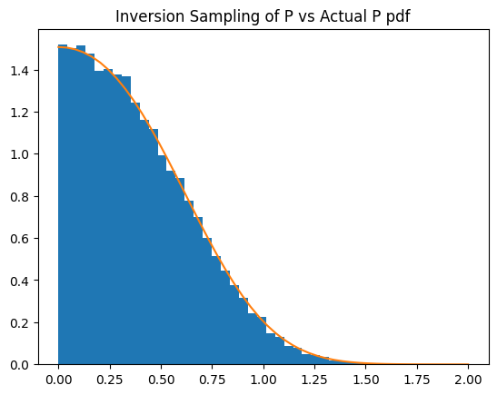

```python
# For parts i and ii see paper work to show
# m = np.exp(5 / 27) and M = m / Z
n = 10**5
m = np.exp(5 / 27)

# Part iii) Rejections sampling
z_sample = np.random.uniform(0, 1, n)
z_sample = -np.log(z_sample)
u_sample = np.random.uniform(0, 1, n)
mask = u_sample <= np.exp(-z_sample**2 - z_sample**3) / (m * np.exp(-z_sample))
P = z_sample[mask]

# Part iv) Plot sample histogram vs pdf
Z = 0.6637
plt.hist(P, bins=40, density=True)
x_axis = np.linspace(0, 2)
plt.plot(x_axis, (1 / Z) * np.exp(-x_axis**2 - x_axis**3))
plt.title("Inversion Sampling of P vs Actual P pdf")
plt.show()
```